# Model Selection for Antenna Data with Explanations

2022-03-25

First we need to upload the data. So:

```r
df_antenna = read.csv('E:/2022/Freelance/Jobs/001-25/data-antenna.csv', header=T)
df_antenna = data.frame(time=df_antenna$Time..hours., fails=df_antenna$Number.of.failures)
```

So we created a new data frame with proper column names. To see what it looks like, we can print the data frame:

```r
df_antenna
```

```
##    time fails
## 1  2000     0
## 2  2300     0
## 3  2430     2
## 4  2600     1
## 5  2750     3
## 6  2900     1
## 7  3010     2
## 8  3140     1
## 9  3200     1
## 10 3240     2
## 11 3500     1
## 12 3650     2
## 13 3800     1
## 14 3940     3
```

[output cut: 21 more lines]

In the second column the number of failures for each time points is recorded. In order to have a complete data set we need to create repetitions of those time points with the frequency of the number of failures. Therefore we repeat each time points relative to their respective number of failures.

```r
time_rep = rep(df_antenna$time, df_antenna$fails)
```

Now we create an empty data frame to hold the information of the distributions that we are going to check.

```r
info_df = data.frame(model=NA, method=NA,Log_likelihood=NA, AIC=NA)
```

In this data frame we have a *model* column which stores the name of the distribution (weibull, gamma, log-normal, beta), a *method* column which stores the method of optimization that is going to be used (mle, mme, qme, mge), and *log-likelihood* and *aic* columns.

Before doing anything, we need to call a library called *fitdistrplus* that will do this process for us. After that we can start checking different distributions with the `fitdist` function.

```r
library(fitdistrplus)
```

# Weibull Distribution

## Weibull with mle

our first method is mle (maximum likelihood estimation):

```r
fit_wei_mle = fitdist(time_rep, 'weibull', method='mle')
info_df[1, ] = c('weibull','MLE',fit_wei_mle$loglik, fit_wei_mle$aic)
```

We can use the `summary()` and `plot()` over this fitted weibull distribution to see its characteristics and how it fits the data using plots.

```r
summary(fit_wei_mle)
```

```
## Fitting of the distribution ' weibull ' by maximum likelihood
## Parameters :
##          estimate  Std. Error
## shape    4.652203   0.5063663
## scale 4929.462884 149.0664872
## Loglikelihood:  -472.2846   AIC:  948.5693   BIC:  952.62
## Correlation matrix:
##           shape     scale
## shape 1.0000000 0.3122859
## scale 0.3122859 1.0000000
```

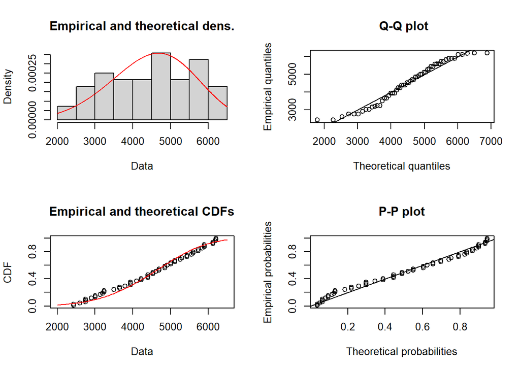

```r
plot(fit_wei_mle)
```

Now we do the same for all other methods and distributions

## Weibull with mme

For the moment matching estimation method we need the moment order of the parameters and a moment function and the `actuar` library for the weibull distribution.

```r
library(actuar)
memp <- function(x, order) mean(x^order)
fit_wei_mme = fitdist(time_rep, 'weibull', method='mme', order=c(1,2), memp=memp)
summary(fit_wei_mme)
```

```
## Fitting of the distribution ' weibull ' by matching moments
## Parameters :
##          estimate
## shape    6.966829
## scale 4885.181396
## Loglikelihood:  -483.5636   AIC:  971.1271   BIC:  975.1779
```

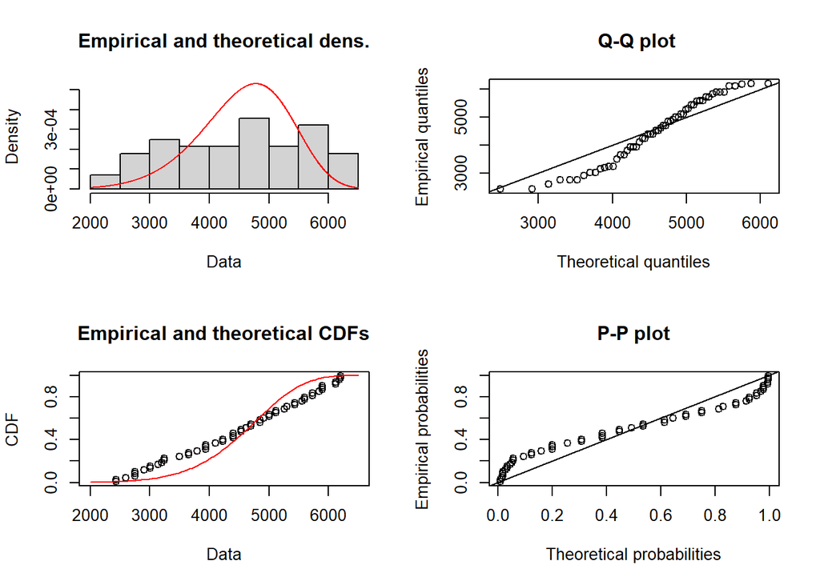

```r
plot(fit_wei_mme)
```

```r
info_df[2, ] = c('weibull','MME',fit_wei_mme$loglik, fit_wei_mme$aic)
```

```r
fit_wei_qme = fitdist(time_rep, 'weibull', method='qme', probs=c(0.5,0.5))
summary(fit_wei_qme)
```

```
## Fitting of the distribution ' weibull ' by matching quantiles
## Parameters :
##         estimate
## shape    4.86911
## scale 4932.66703
## Loglikelihood:  -472.3821   AIC:  948.7641   BIC:  952.8148
```

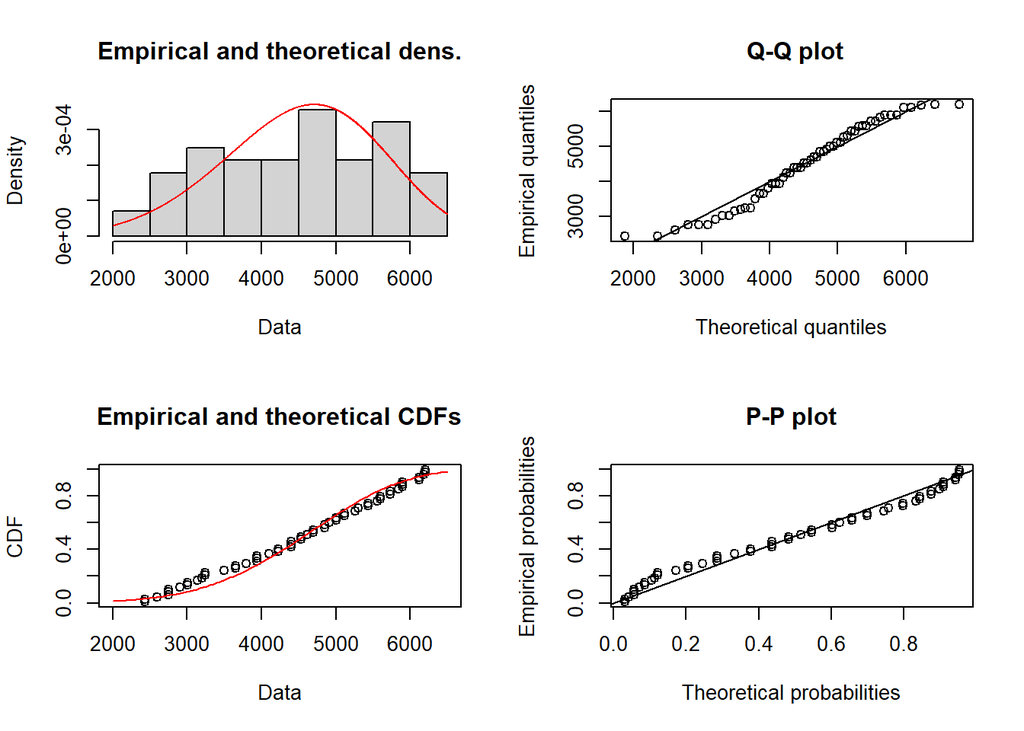

```r
plot(fit_wei_qme)
```

```r
info_df[3, ] = c('weibull','QME',fit_wei_qme$loglik, fit_wei_qme$aic)
```

```r
fit_wei_mge = fitdist(time_rep, 'weibull', method='mge', gof='KS')
summary(fit_wei_mge)
```

```
## Fitting of the distribution ' weibull ' by maximum goodness-of-fit
## Parameters :
##          estimate
## shape    4.175238
## scale 4902.676461
## Loglikelihood:  -472.7618   AIC:  949.5235   BIC:  953.5742
```

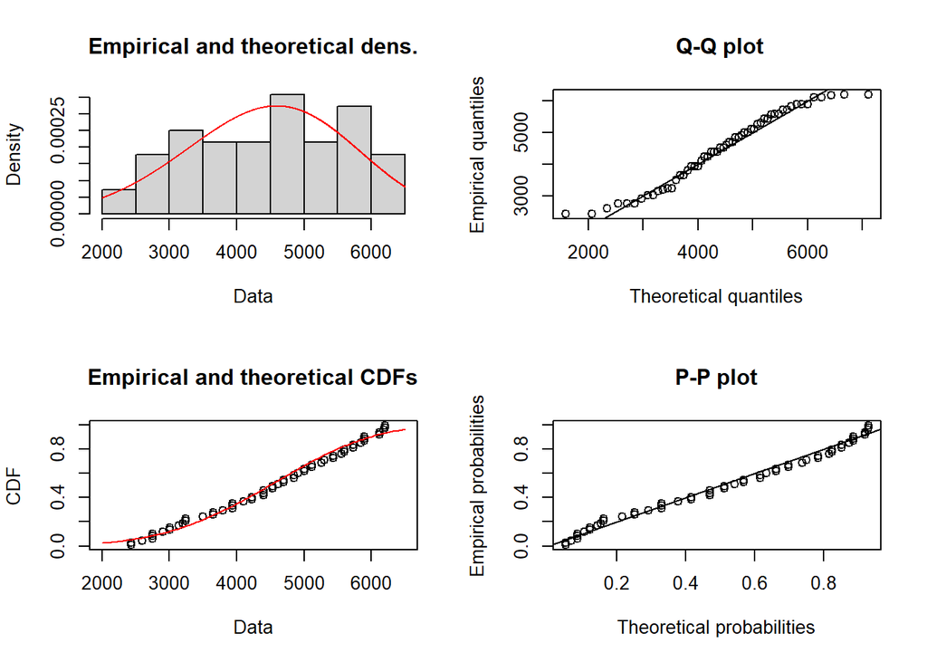

```r
plot(fit_wei_mge)
```

```r
info_df[4, ] = c('weibull','MGE KS',fit_wei_mge$loglik, fit_wei_mge$aic)
```

## Weibull with gme (CvM)

```r
fit_wei_mge.2 = fitdist(time_rep, 'weibull', method='mge', gof='CvM')
summary(fit_wei_mge.2)
```

```
## Fitting of the distribution ' weibull ' by maximum goodness-of-fit
## Parameters :
##          estimate
## shape    4.027703
## scale 4987.383613
## Loglikelihood:  -473.361   AIC:  950.7221   BIC:  954.7728
```

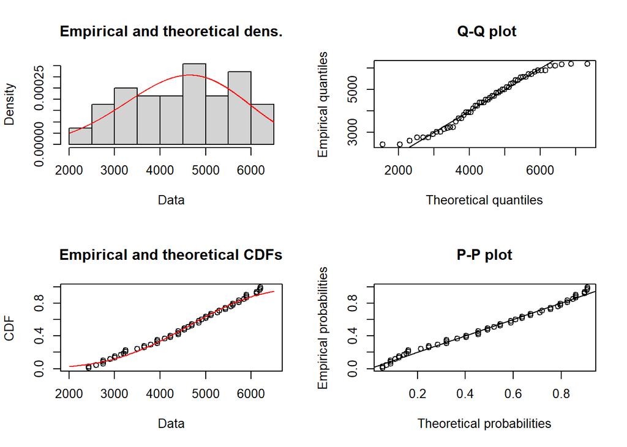

```r
plot(fit_wei_mge.2)
```

```r
info_df[5, ] = c('weibull','MGE CvM',fit_wei_mge.2$loglik, fit_wei_mge.2$aic)
```

## Weibull with gme (AD)

```r
fit_wei_mge.3 = fitdist(time_rep, 'weibull', method='mge', gof='AD')
summary(fit_wei_mge.3)
```

```
## Fitting of the distribution ' weibull ' by maximum goodness-of-fit
## Parameters :
##          estimate
## shape    4.157373
## scale 4960.392029
## Loglikelihood:  -472.9118   AIC:  949.8236   BIC:  953.8743
```

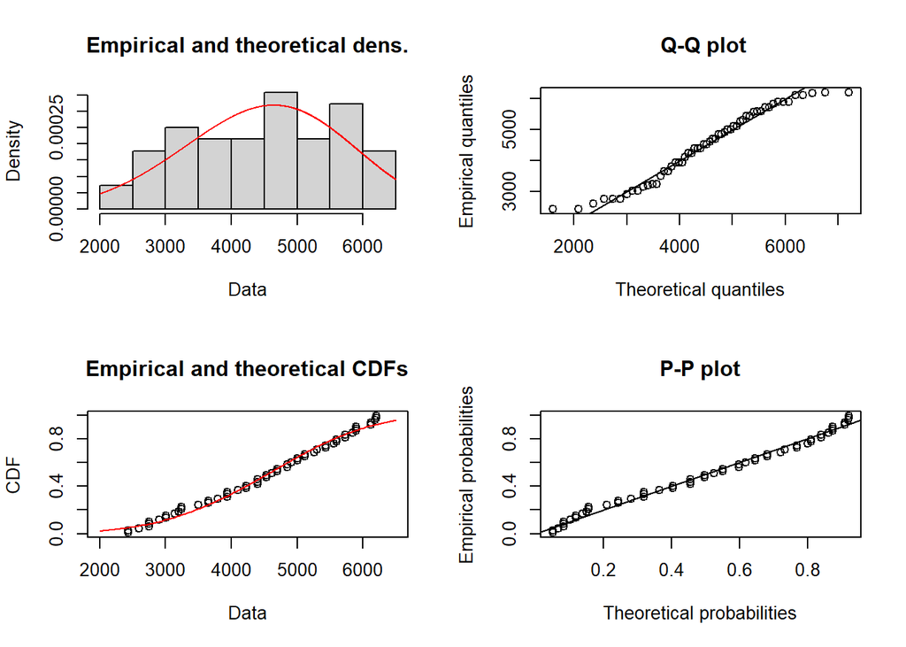

```r
plot(fit_wei_mge.3)
```

```r
info_df[6, ] = c('weibull','MGE AD',fit_wei_mge.3$loglik, fit_wei_mge.3$aic)
```

Now we can do this whole process for the other 3 distributions.

# Gamma Distribution

```r
# MLE
fit_gam_mle = fitdist(time_rep, 'gamma', method='mle')
summary(fit_gam_mle)
```

```
## Fitting of the distribution ' gamma ' by maximum likelihood
## Parameters :
##          estimate   Std. Error
## shape 14.32018758 1.1511231066
## rate   0.00318813 0.0002313614
## Loglikelihood:  -474.5652   AIC:  953.1304   BIC:  957.1811
## Correlation matrix:
##           shape      rate
## shape 1.0000000 0.9020393
## rate  0.9020393 1.0000000
```

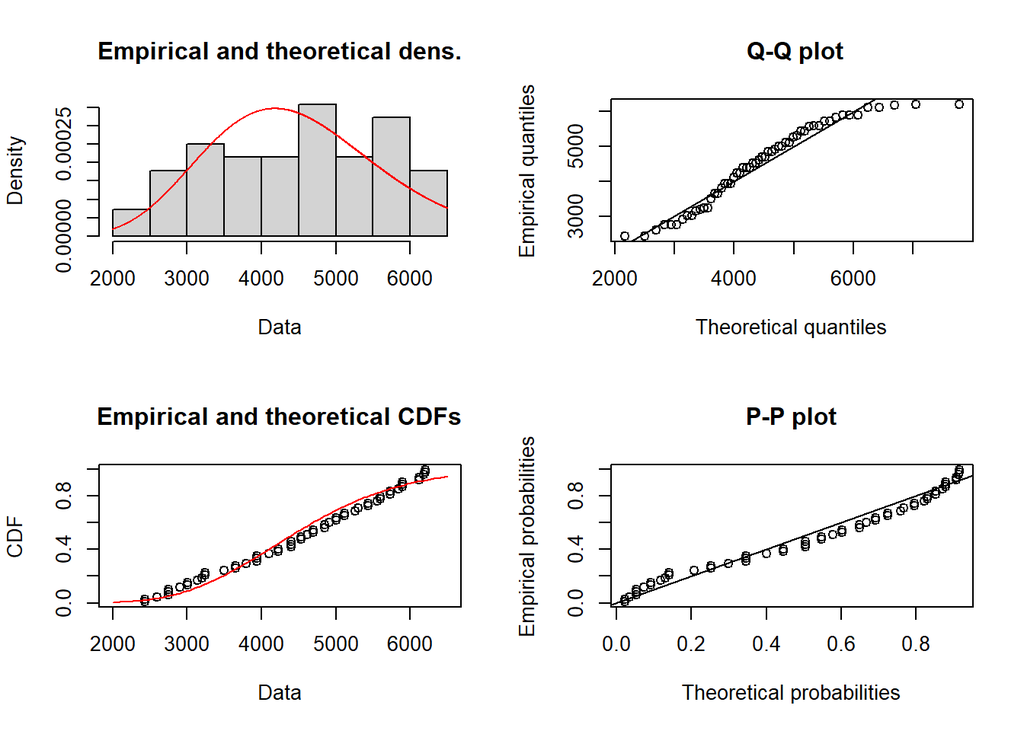

```r
plot(fit_gam_mle)
```

```r
info_df[7, ] = c('gamma','MLE',fit_gam_mle$loglik, fit_gam_mle$aic)

# MME
fit_gam_mme = fitdist(time_rep, 'gamma', method='mme')
summary(fit_gam_mme)
```

```
## Fitting of the distribution ' gamma ' by matching moments
## Parameters :
##           estimate
## shape 15.670640372
## rate   0.003488455
## Loglikelihood:  -474.6843   AIC:  953.3687   BIC:  957.4194
```

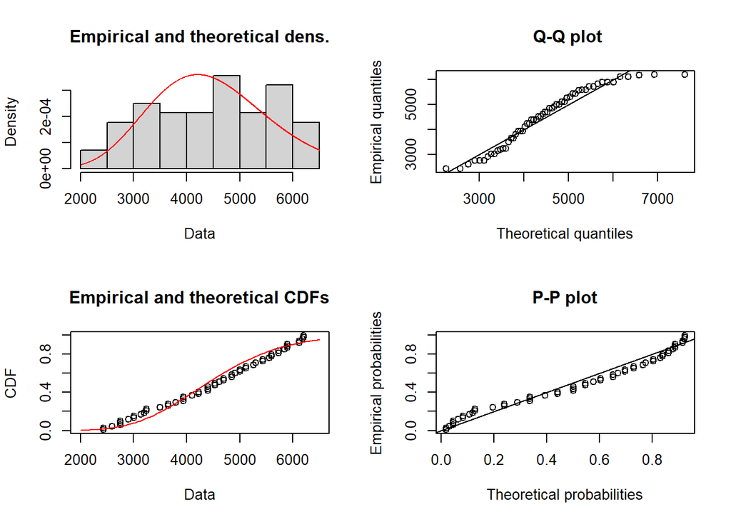

```r
plot(fit_gam_mme)
```

```r
info_df[8, ] = c('gamma','MME',fit_gam_mme$loglik, fit_gam_mme$aic)

# QME
fit_gam_qme = fitdist(time_rep, 'gamma', method='qme', probs=c(0.5,0.5))
summary(fit_gam_qme)
```

```
## Fitting of the distribution ' gamma ' by matching quantiles
## Parameters :
##           estimate
## shape 16.013862871
## rate   0.003427711
## Loglikelihood:  -475.4313   AIC:  954.8625   BIC:  958.9132
```

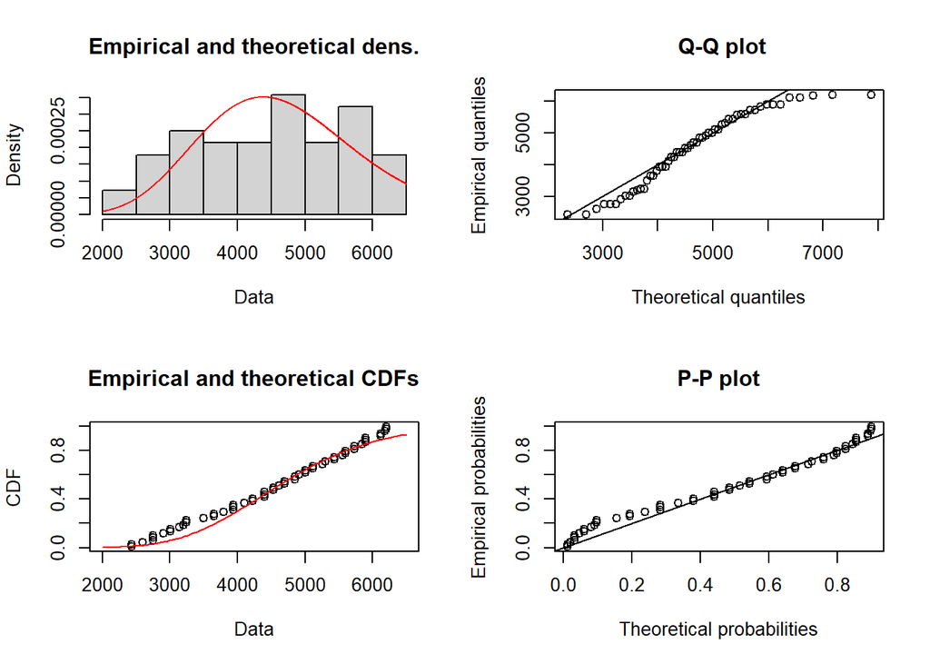

```r
plot(fit_gam_qme)
```

```r
info_df[9, ] = c('gamma','QME',fit_gam_qme$loglik, fit_gam_qme$aic)

# MGE
fit_gam_mge = fitdist(time_rep, 'gamma', method='mge', gof='KS')
summary(fit_gam_mge)
```

```
## Fitting of the distribution ' gamma ' by maximum goodness-of-fit
## Parameters :
##           estimate
## shape 13.831061382
## rate   0.003069478
## Loglikelihood:  -474.5862   AIC:  953.1725   BIC:  957.2232
```

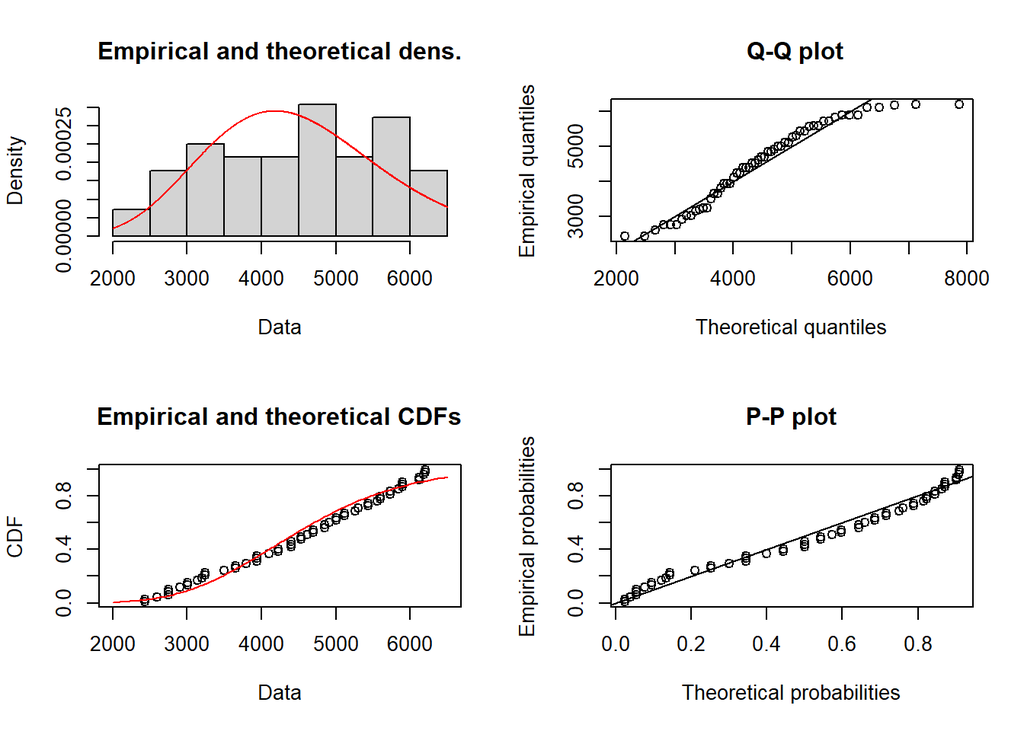

```r
plot(fit_gam_mge)
```

```r
info_df[10, ] = c('gamma','MGE KS',fit_gam_mge$loglik, fit_gam_mge$aic)

fit_gam_mge.3 = fitdist(time_rep, 'gamma', method='mge', gof='AD')
summary(fit_gam_mge.3)
```

```
## Fitting of the distribution ' gamma ' by maximum goodness-of-fit
## Parameters :
##           estimate
## shape 11.937720022
## rate   0.002615111
## Loglikelihood:  -475.0997   AIC:  954.1995   BIC:  958.2502
```

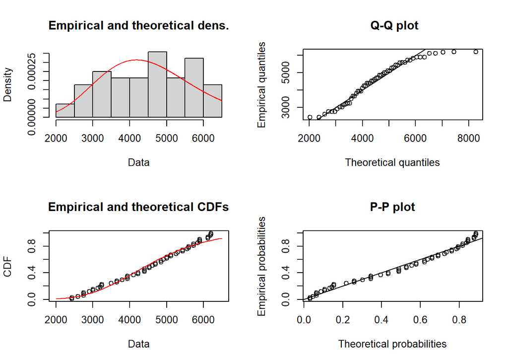

```r
plot(fit_gam_mge.3)
```

```r
info_df[11, ] = c('gamma','MGE AD',fit_gam_mge.3$loglik, fit_gam_mge.3$aic)
```

The only exception here, is that when we use CvM goodness-of-fit distance it cannot perform the optimization process and returns and error. Therefore it is not mentioned here.

# Log-normal Distribution

```r
# MLE
fit_lnorm_mle = fitdist(time_rep, 'lnorm', method='mle')
summary(fit_lnorm_mle)
```

```
## Fitting of the distribution ' lnorm ' by maximum likelihood
## Parameters :
##          estimate Std. Error
## meanlog 8.3747724 0.03650999
## sdlog   0.2732157 0.02581490
## Loglikelihood:  -475.7882   AIC:  955.5763   BIC:  959.627
## Correlation matrix:
##               meanlog         sdlog
## meanlog  1.000000e+00 -1.339375e-11
## sdlog   -1.339375e-11  1.000000e+00
```

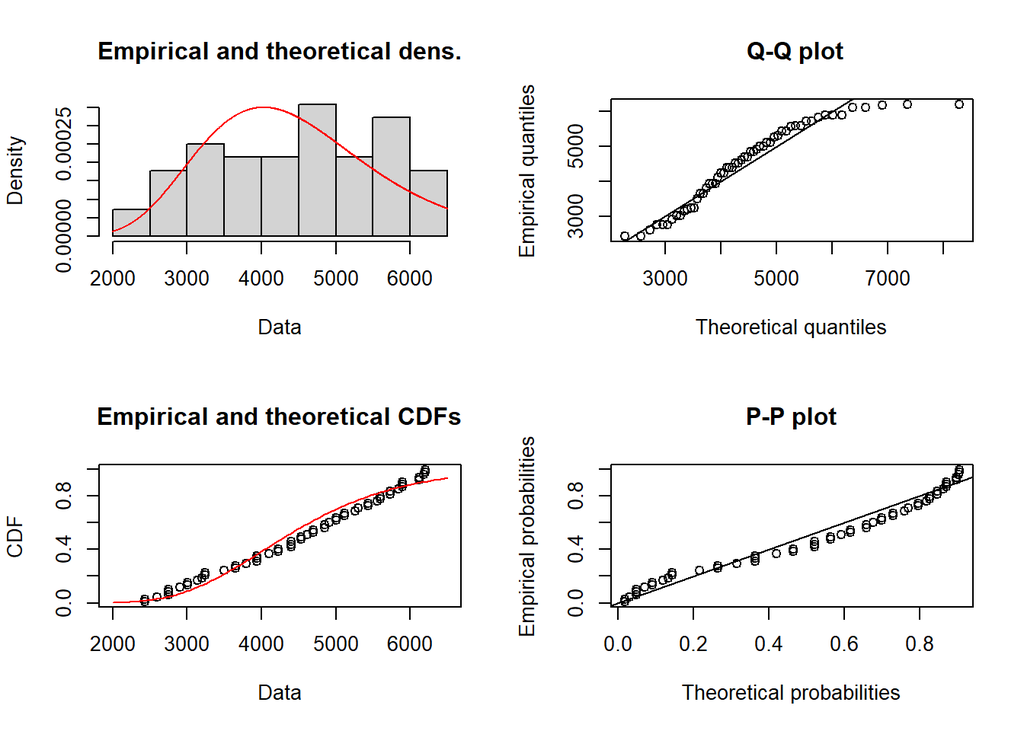

```r
plot(fit_lnorm_mle)
```

```r
info_df[12, ] = c('lnorm','MLE',fit_lnorm_mle$loglik, fit_lnorm_mle$aic)

# MME
fit_lnorm_mme = fitdist(time_rep, 'lnorm', method='mme')
summary(fit_lnorm_mme)
```

```
## Fitting of the distribution ' lnorm ' by matching moments
## Parameters :
##          estimate
## meanlog 8.3791550
## sdlog   0.2487171
## Loglikelihood:  -476.3236   AIC:  956.6471   BIC:  960.6978
```

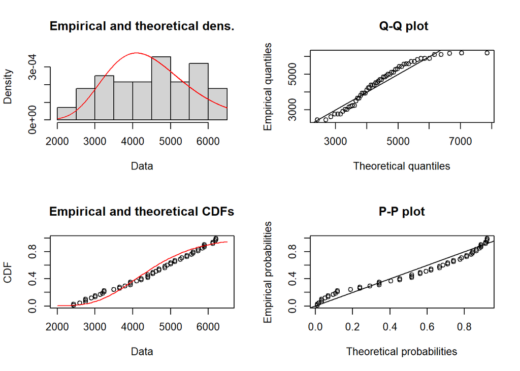

```r
plot(fit_lnorm_mme)
```

```r
info_df[13, ] = c('lnorm','MME',fit_lnorm_mme$loglik, fit_lnorm_mme$aic)

# QME
fit_lnorm_qme = fitdist(time_rep, 'lnorm', method='qme', probs=c(0.5,0.5))
summary(fit_lnorm_qme)
```

```
## Fitting of the distribution ' lnorm ' by matching quantiles
## Parameters :
##          estimate
## meanlog 8.4283641
## sdlog   0.7617729
## Loglikelihood:  -508.9502   AIC:  1021.9   BIC:  1025.951
```

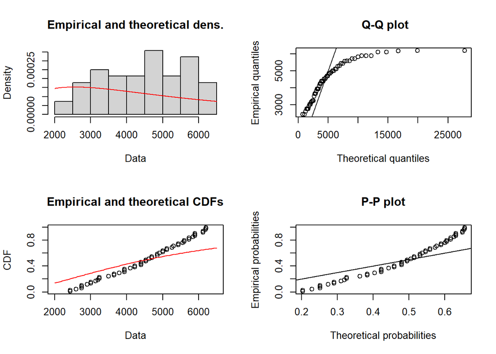

```r
plot(fit_lnorm_qme)
```

```r
info_df[14, ] = c('lnorm','QME',fit_lnorm_qme$loglik, fit_lnorm_qme$aic)

# MGE
fit_lnorm_mge = fitdist(time_rep, 'lnorm', method='mge', gof='KS')
summary(fit_lnorm_mge)
```

```
## Fitting of the distribution ' lnorm ' by maximum goodness-of-fit
## Parameters :
##          estimate
## meanlog 8.3831953
## sdlog   0.2704497
## Loglikelihood:  -475.8212   AIC:  955.6423   BIC:  959.693
```

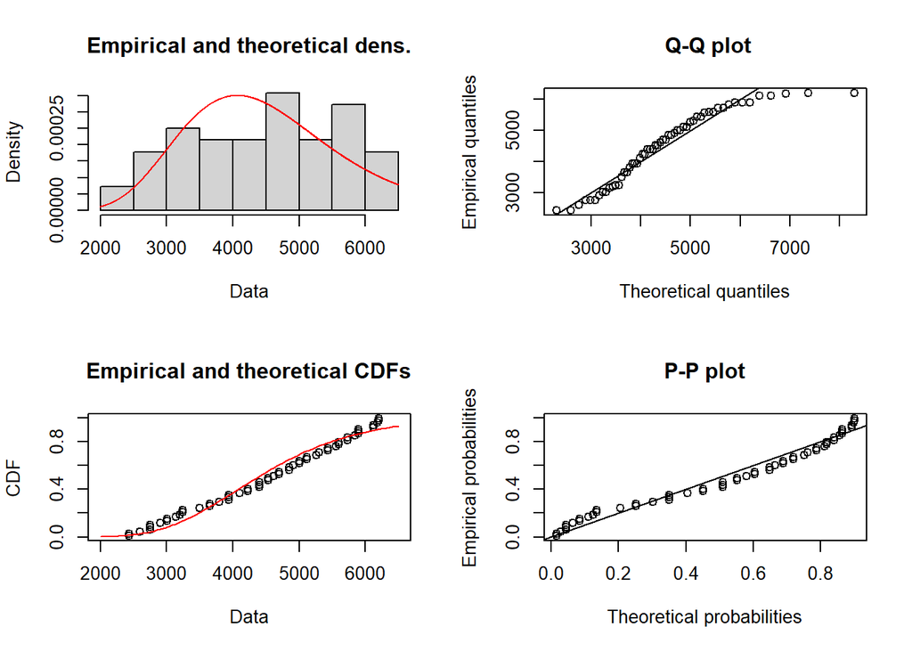

```r
plot(fit_lnorm_mge)
```

```r
info_df[15, ] = c('lnorm','MGE KS',fit_lnorm_mge$loglik, fit_lnorm_mge$aic)

fit_lnorm_mge.2 = fitdist(time_rep, 'lnorm', method='mge', gof='CvM')
summary(fit_lnorm_mge.2)
```

```
## Fitting of the distribution ' lnorm ' by maximum goodness-of-fit
## Parameters :
##          estimate
## meanlog 8.4028642
## sdlog   0.2945195
## Loglikelihood:  -476.3434   AIC:  956.6868   BIC:  960.7375
```

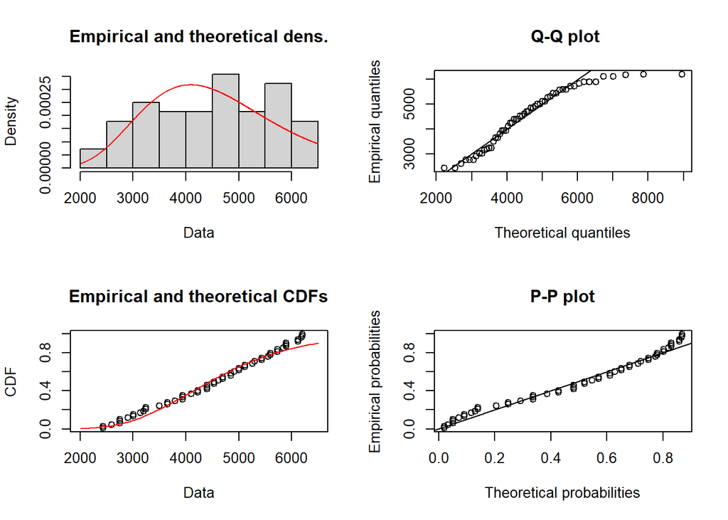

```r
plot(fit_lnorm_mge.2)
```

```r
info_df[16, ] = c('lnorm','MGE CvM',fit_lnorm_mge.2$loglik, fit_lnorm_mge.2$aic)

fit_lnorm_mge.3 = fitdist(time_rep, 'lnorm', method='mge', gof='AD')
summary(fit_lnorm_mge.3)
```

```
## Fitting of the distribution ' lnorm ' by maximum goodness-of-fit
## Parameters :
##          estimate
## meanlog 8.3891468
## sdlog   0.2998303
## Loglikelihood:  -476.3078   AIC:  956.6155   BIC:  960.6662
```

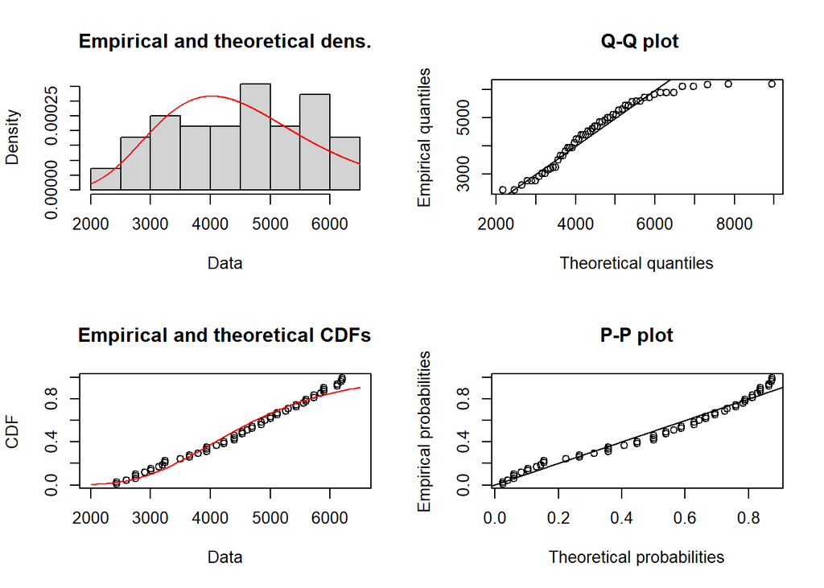

```r
plot(fit_lnorm_mge.3)
```

```r
info_df[17, ] = c('lnorm','MGE AD',fit_lnorm_mge.3$loglik, fit_lnorm_mge.3$aic)
```

# Beta Distribution

For the beta distribution we need to make some adjustments since this distribution needs our data to be within [0-1] interval. We can achieve this by simply dividing our time points to 10000.

```r
time_rep_beta = time_rep/10000
```

Now we can check different methods for this distribution.

```r
# MLE
fit_beta_mle = fitdist(time_rep_beta, 'beta', method='mle')
summary(fit_beta_mle)
```

```
## Fitting of the distribution ' beta ' by maximum likelihood
## Parameters :
##         estimate Std. Error
## shape1  8.328603   1.549325
## shape2 10.234831   1.914655
## Loglikelihood:  43.08414   AIC:  -82.16827   BIC:  -78.11757
## Correlation matrix:
##          shape1   shape2
## shape1 1.000000 0.947095
## shape2 0.947095 1.000000
```

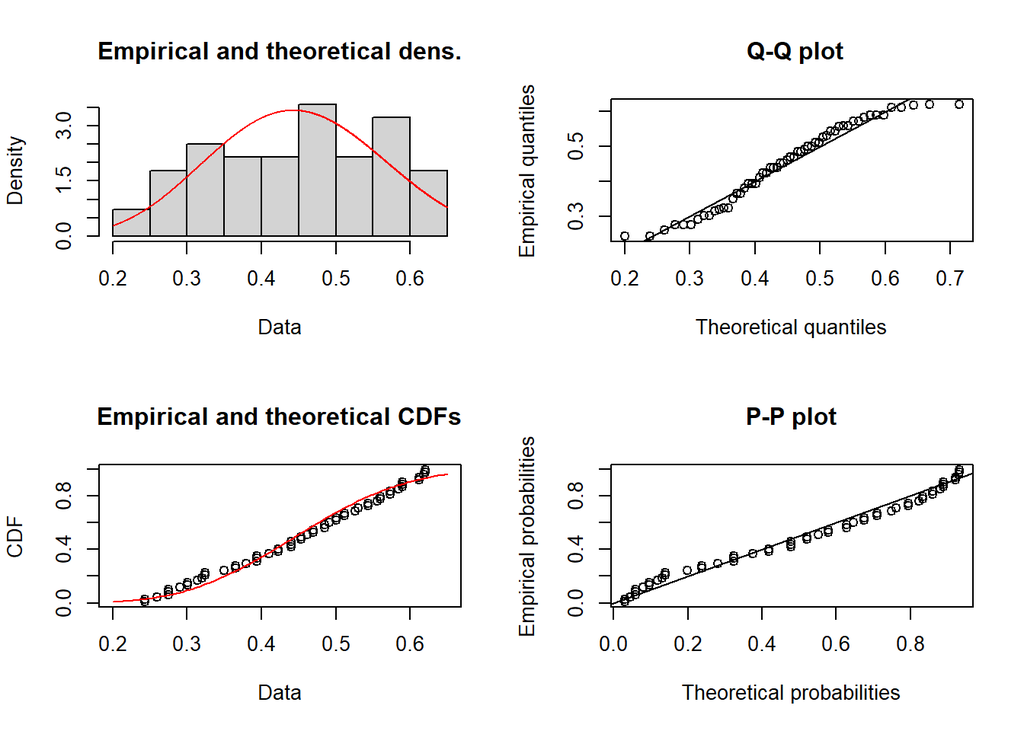

```r
plot(fit_beta_mle)
```

```r
info_df[18, ] = c('beta','MLE',fit_beta_mle$loglik, fit_beta_mle$aic)

# MME
fit_beta_mme = fitdist(time_rep_beta, 'beta', method='mme')
summary(fit_beta_mme)
```

```
## Fitting of the distribution ' beta ' by matching moments
## Parameters :
##         estimate
## shape1  8.181951
## shape2 10.031964
## Loglikelihood:  43.07826   AIC:  -82.15652   BIC:  -78.10581
```

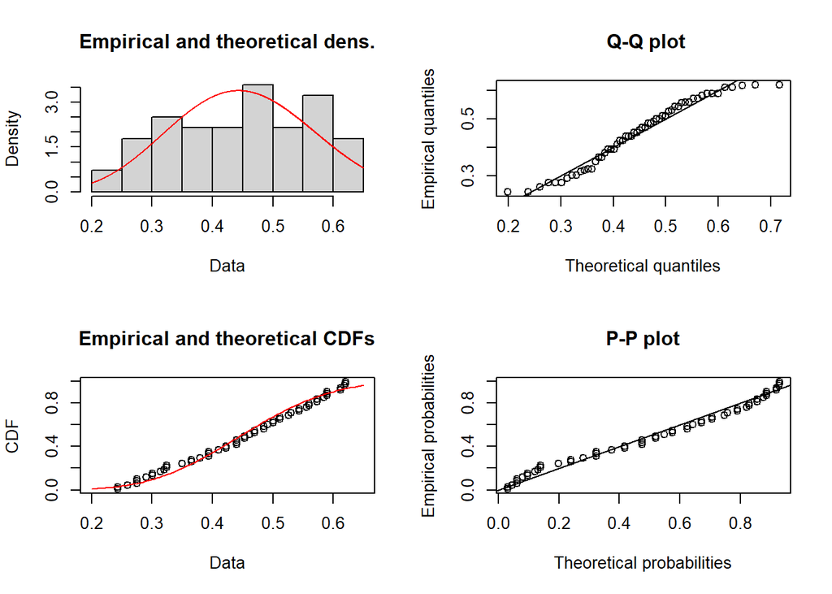

```r
plot(fit_beta_mme)
```

```r
info_df[19, ] = c('beta','MME',fit_beta_mme$loglik, fit_beta_mme$aic)

# QME
fit_beta_qme = fitdist(time_rep_beta, 'beta', method='qme', probs=c(0.5,0.5))
summary(fit_beta_qme)
```

```
## Fitting of the distribution ' beta ' by matching quantiles
## Parameters :
##         estimate
## shape1  8.653411
## shape2 10.200147
## Loglikelihood:  42.83844   AIC:  -81.67688   BIC:  -77.62617
```

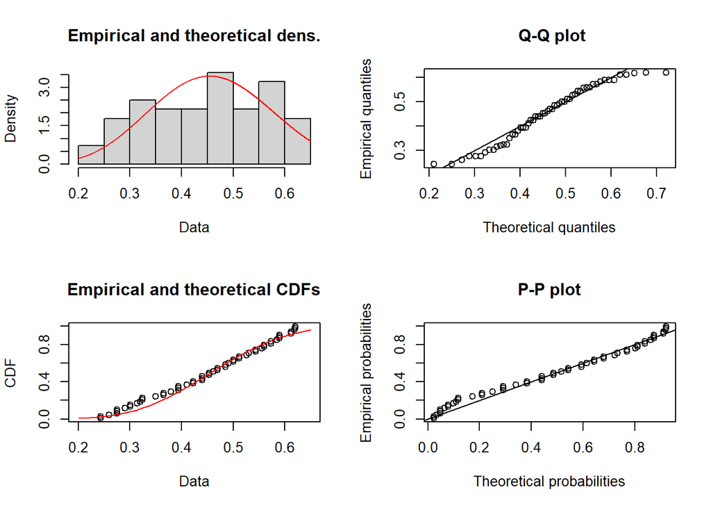

```r
plot(fit_beta_qme)
```

```r
info_df[20, ] = c('beta','QME',fit_beta_qme$loglik, fit_beta_qme$aic)

# MGE
fit_beta_mge = fitdist(time_rep_beta, 'beta', method='mge', gof='KS')
summary(fit_beta_mge)
```

```
## Fitting of the distribution ' beta ' by maximum goodness-of-fit
## Parameters :
##        estimate
## shape1 7.475966
## shape2 9.273041
## Loglikelihood:  42.91936   AIC:  -81.83873   BIC:  -77.78802
```

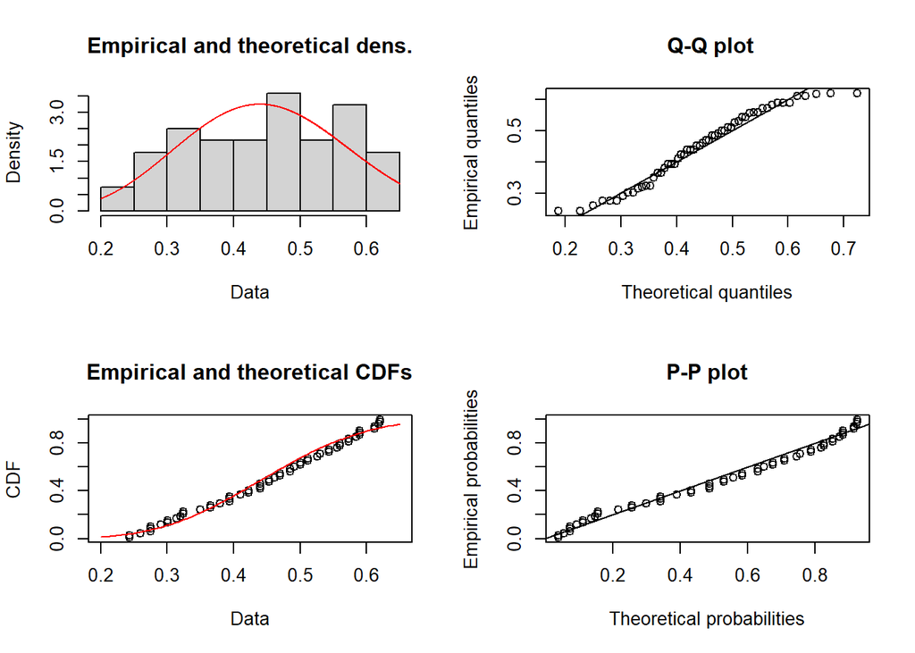

```r
plot(fit_beta_mge)
```

```r
info_df[21, ] = c('beta','MGE KS',fit_beta_mge$loglik, fit_beta_mge$aic)

fit_beta_mge.2 = fitdist(time_rep_beta, 'beta', method='mge', gof='CvM')
summary(fit_beta_mge.2)
```

```
## Fitting of the distribution ' beta ' by maximum goodness-of-fit
## Parameters :
##        estimate
## shape1 6.625676
## shape2 7.945644
## Loglikelihood:  42.23215   AIC:  -80.46431   BIC:  -76.41361
```

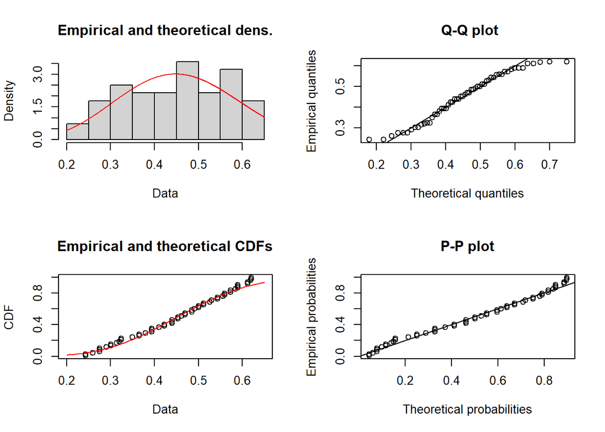

```r
plot(fit_beta_mge.2)
```

```r
info_df[22, ] = c('beta','MGE CvM',fit_beta_mge.2$loglik, fit_beta_mge.2$aic)

fit_beta_mge.3 = fitdist(time_rep_beta, 'beta', method='mge', gof='AD')
summary(fit_beta_mge.3)
```

```
## Fitting of the distribution ' beta ' by maximum goodness-of-fit
## Parameters :
##        estimate
## shape1 6.938480
## shape2 8.412142
## Loglikelihood:  42.56778   AIC:  -81.13556   BIC:  -77.08485
```

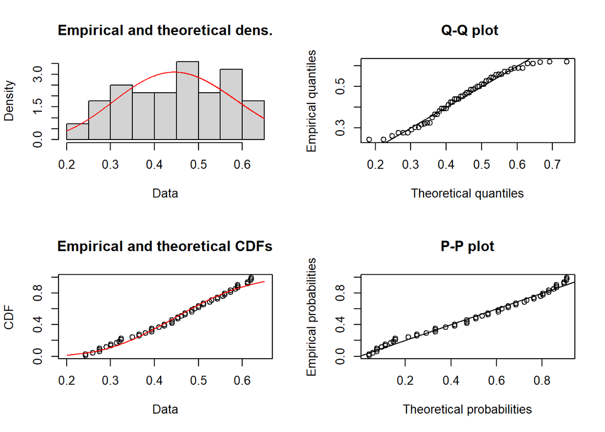

```r
plot(fit_beta_mge.3)
```

```r
info_df[23, ] = c('beta','MGE AD',fit_beta_mge.3$loglik, fit_beta_mge.3$aic)
```

Now that we have stored all the required information in the `info_df` data frame, we can simply output it to compare different methods and different distributions.

```r
info_df
```

```
##      model  method    Log_likelihood               AIC
## 1  weibull     MLE -472.284637114282  948.569274228565
## 2  weibull     MME -483.563574108411  971.127148216822
## 3  weibull     QME -472.382072831394  948.764145662787
## 4  weibull  MGE KS -472.761772472635  949.523544945271
## 5  weibull MGE CvM -473.361036563993  950.722073127986
## 6  weibull  MGE AD -472.911789996086  949.823579992172
## 7    gamma     MLE -474.565205087577  953.130410175154
## 8    gamma     MME -474.684343277123  953.368686554246
## 9    gamma     QME -475.431256030569  954.862512061137
## 10   gamma  MGE KS -474.586231259035  953.172462518069
## 11   gamma  MGE AD -475.099747792793  954.199495585585
## 12   lnorm     MLE -475.788169247699  955.576338495397
## 13   lnorm     MME -476.323571378329  956.647142756657
## 14   lnorm     QME -508.950204596739  1021.90040919348
## 15   lnorm  MGE KS -475.821165521356  955.642331042711
## 16   lnorm MGE CvM -476.343379361363  956.686758722726
## 17   lnorm  MGE AD  -476.30775733488  956.615514669761
## 18    beta     MLE  43.0841361796381 -82.1682723592762
## 19    beta     MME  43.0782577327288 -82.1565154654576
## 20    beta     QME  42.8384387101785 -81.6768774203569
## 21    beta  MGE KS  42.9193628199429 -81.8387256398859
## 22    beta MGE CvM  42.2321544099732 -80.4643088199464
## 23    beta  MGE AD  42.5677791610173 -81.1355583220347
```

To interpret the results, We need to find the distribution with highest log-likelihood value and lowest aic value. As you can see, the best distribution is beta with maximum likelihood estimation method.

Here you can see this distribution fit again which estimates the parameters

```r
fit_beta_mle
```

```
## Fitting of the distribution ' beta ' by maximum likelihood
## Parameters:
##         estimate Std. Error
## shape1  8.328603   1.549325
## shape2 10.234831   1.914655
```

The `fitdistrplus` package also has a function called `descdist` that can check different distributions fitness to our data which as you can see gives the same results.

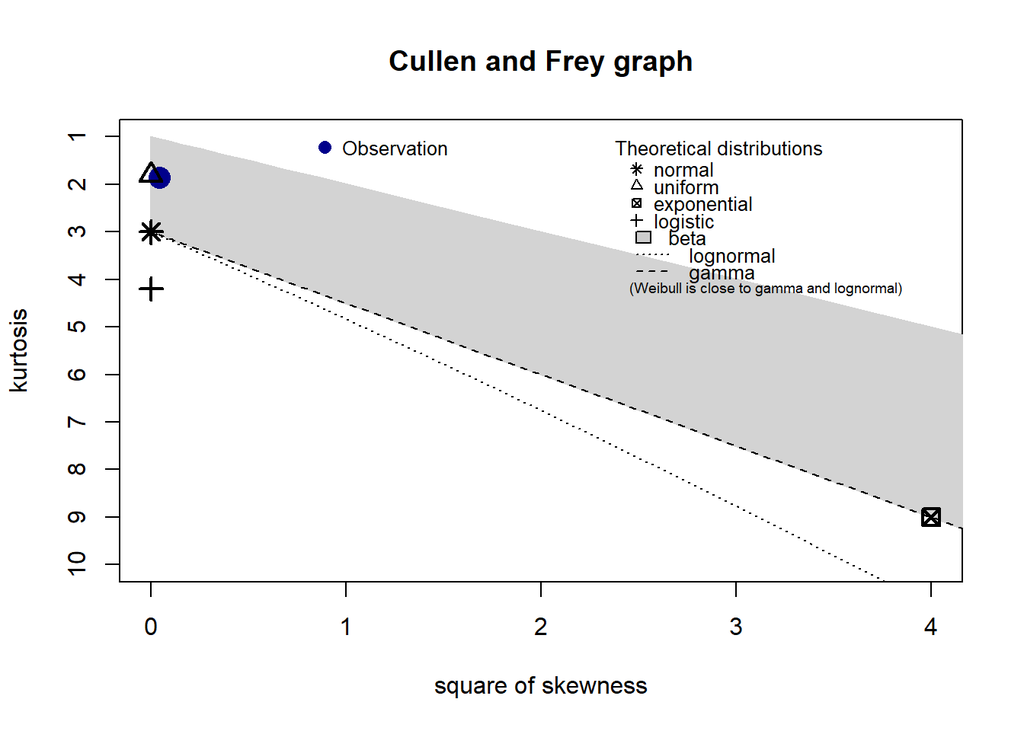

```
## summary statistics
## ------
## min:  2430   max:  6200
## median:  4575
## mean:  4492.143
## estimated sd:  1145.046
## estimated skewness:  -0.2117992
## estimated kurtosis:  1.862342
```

```r
descdist(time_rep)
```

Therefore our chosen model is the beta distribution with parameters 8.3286026 as shape1, and 10.2348312 as shape2.

## Failure Probability and Reliability

Failure probability and reliability are complimentary of each other, as $R(t) = 1 - F(t)$. Therefore, 5% failure probability equals 95% reliability and vice versa. In order to find the 5% failure probability we can use the `qbeta` function to find the quantile of the optimal beta distribution that produces 5% failure probability or is reliable 95% of the time.

```r
fail_quant = qbeta(0.05, fit_beta_mle$estimate[1], fit_beta_mle$estimate[2])
```

Remember that with beta distribution, we divided the time points to 10000. We can now multiply this number to reach the time point that produces 95% reliability.

Therefore:

```r
fail_quant = fail_quant*10000
fail_quant
```

```
## [1] 2665.029
```

Therefore at 2665.03 hours, 95% of the systems are still working.